# Part I - San Francisco Bike Share Data Exploration

## Introduction

> This document explores a dataset containing demographics, locations, and datetime attributes for approximately 180,000 bike-share riders.

## Preliminary Wrangling

```python
# import all packages and set plots to be embedded inline
import numpy as np
import pandas as pd
import matplotlib.pyplot as plt
import seaborn as sb

%matplotlib inline
pd.set_option('display.max_columns', None)
```

```python
# load in dataset
gobike = pd.read_csv('201902-fordgobike-tripdata.csv')
```

```python
# dimensions of data set
gobike.shape
```

```
(183412, 16)
```

```python
# data types
gobike.info()
```

```
<class 'pandas.core.frame.DataFrame'>
RangeIndex: 183412 entries, 0 to 183411
Data columns (total 16 columns):
 #   Column                   Non-Null Count   Dtype
---  ------                   --------------   -----
 0   duration_sec             183412 non-null  int64
 1   start_time               183412 non-null  object
 2   end_time                 183412 non-null  object
 3   start_station_id         183215 non-null  float64
 4   start_station_name       183215 non-null  object
 5   start_station_latitude   183412 non-null  float64
 6   start_station_longitude  183412 non-null  float64
 7   end_station_id           183215 non-null  float64
 8   end_station_name         183215 non-null  object
 9   end_station_latitude     183412 non-null  float64
 10  end_station_longitude    183412 non-null  float64
 11  bike_id                  183412 non-null  int64
 12  user_type                183412 non-null  object
 13  member_birth_year        175147 non-null  float64
 14  member_gender            175147 non-null  object
 15  bike_share_for_all_trip  183412 non-null  object
dtypes: float64(7), int64(2), object(7)
memory usage: 22.4+ MB
```

```python
# drop nan values
gobike.dropna(inplace=True)
```

```python
gobike.describe()
```

|  | duration_sec | start_station_id | start_station_latitude | start_station_longitude | end_station_id | end_station_latitude | end_station_longitude | bike_id | member_birth_year |
| --- | --- | --- | --- | --- | --- | --- | --- | --- | --- |
| count | 174952.000000 | 174952.000000 | 174952.000000 | 174952.000000 | 174952.000000 | 174952.000000 | 174952.000000 | 174952.000000 | 174952.000000 |
| mean | 704.002744 | 139.002126 | 37.771220 | -122.351760 | 136.604486 | 37.771414 | -122.351335 | 4482.587555 | 1984.803135 |
| std | 1642.204905 | 111.648819 | 0.100391 | 0.117732 | 111.335635 | 0.100295 | 0.117294 | 1659.195937 | 10.118731 |
| min | 61.000000 | 3.000000 | 37.317298 | -122.453704 | 3.000000 | 37.317298 | -122.453704 | 11.000000 | 1878.000000 |
| 25% | 323.000000 | 47.000000 | 37.770407 | -122.411901 | 44.000000 | 37.770407 | -122.411647 | 3799.000000 | 1980.000000 |
| 50% | 510.000000 | 104.000000 | 37.780760 | -122.398279 | 101.000000 | 37.781010 | -122.397437 | 4960.000000 | 1987.000000 |
| 75% | 789.000000 | 239.000000 | 37.797320 | -122.283093 | 238.000000 | 37.797673 | -122.286533 | 5505.000000 | 1992.000000 |
| max | 84548.000000 | 398.000000 | 37.880222 | -121.874119 | 398.000000 | 37.880222 | -121.874119 | 6645.000000 | 2001.000000 |

```python
gobike.head(1)
```

|  | duration_sec | start_time | end_time | start_station_id | start_station_name | start_station_latitude | start_station_longitude | end_station_id | end_station_name | end_station_latitude | end_station_longitude | bike_id | user_type | member_birth_year | member_gender | bike_share_for_all_trip |
| --- | --- | --- | --- | --- | --- | --- | --- | --- | --- | --- | --- | --- | --- | --- | --- | --- |
| 0 | 52185 | 2019-02-28 17:32:10.1450 | 2019-03-01 08:01:55.9750 | 21.0 | Montgomery St BART Station (Market St at 2nd St) | 37.789625 | -122.400811 | 13.0 | Commercial St at Montgomery St | 37.794231 | -122.402923 | 4902 | Customer | 1984.0 | Male | No |

### What is the structure of your dataset?

> There are a little over 180,000 bike share entries in the original dataset with 16 variables (duration in seconds, start-time, end-time, start station id, name, latitude, longtitue, end station id, name, latitude, longtitude, bike id, user type, user birth year, user gender, bike share for all trip). Most variables are numeric in nature, with the exception of categorical entries such as user type, station name, and date/time. There are some unusual outliers in members' birth year, and ride duration in seconds which I will address.

### What is/are the main feature(s) of interest in your dataset?

> I am most interested in finding answers to: What are the demographics of the people that use the bike share service? What proportion of the customers that are subscribers? What is the busiest day of the week? How long do customer use the bikes for, and how far do they go with the bikes before returning them.

### What features in the dataset do you think will help support your investigation into your feature(s) of interest?

> I expect the customer birth year, gender, start and end times will be most helpful to answer my questions of by whom, and when the bike share is used the most.

## Univariate Exploration

> In this section, I will investigate the distributions of individual variables starting with customer age.

### User Demographics

- There are some outliers in the members birth years such as an entry of 1878. The amount of outliers are insignificant in numbers, however they do skew the graphs. I will remove them keeping the data within 5 standard deviation from the mean.

```python
# keep only the ones that are within +5 to -5 standard deviations in the column 'member_birth_year'.
gobike = gobike[np.abs(gobike.member_birth_year-gobike.member_birth_year.mean()) <= (5*gobike.member_birth_year.std())]
```

```python
# change data type of member_birth_year
gobike['member_birth_year'] = gobike['member_birth_year'].astype(int)

# create customer_age column and calculate customers' ages
today = 2022
gobike['customer_age'] = today - gobike['member_birth_year']
```

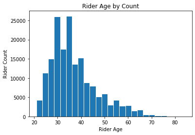

```python
plt.hist(data=gobike, x='customer_age', bins=25, edgecolor='white')
plt.xlabel('Rider Age')
plt.ylabel('Rider Count')
plt.title('Rider Age by Count');
```

- The largest amount of data are from customers aged between 25-40.

```python
base_color = sb.color_palette()[0]
```

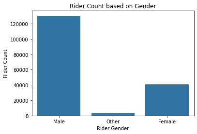

```python
sb.countplot(data=gobike, x='member_gender', color=base_color)
plt.xlabel('Rider Gender')
plt.ylabel('Rider Count')
plt.title('Rider Count based on Gender');
```

- The customers are predominantly male customers.

### Duration of rides

```python
# keep only the ones that are within +3.5 to -3.5 standard deviations in the column 'duration_sec'.
gobike = gobike[np.abs(gobike.duration_sec-gobike.duration_sec.mean()) <= (3.5*gobike.duration_sec.std())]
```

```python
gobike.duration_sec.describe()
```

```
count    174137.000000
mean        636.550297
std         521.125871
min          61.000000
25%         323.000000
50%         509.000000
75%         785.000000
max        6449.000000
Name: duration_sec, dtype: float64
```

```python
gobike['duration_min'] = gobike['duration_sec'] / 60
gobike.duration_min = gobike.duration_min.astype(int)
```

```python
gobike.duration_min.describe(),
```

```
(count    174137.00000
 mean         10.11727
 std           8.69023
 min           1.00000
 25%           5.00000
 50%           8.00000
 75%          13.00000
 max         107.00000
 Name: duration_min, dtype: float64,)
```

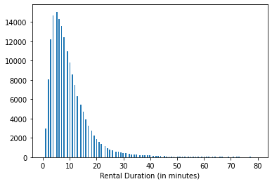

```python
plt.hist(data=gobike, x='duration_min', bins=np.arange(0, 80, 0.45))
plt.xlabel('Rental Duration (in minutes)');
```

- Most rentals were less than 20 minutes long.There is a long tail to the right because of a few outliers in duration.

## Daily rider behaviour

```python
# change data type for start and end times
gobike['start_time'] = gobike['start_time'].astype('datetime64')
gobike['end_time'] = gobike['end_time'].astype('datetime64')
```

```python
# get day of the month
gobike['day'] = gobike['start_time'].apply(lambda r:r.day)
```

```python
# get day of the week from start_time
from datetime import datetime

gobike['day_of_week'] = gobike['start_time'].dt.day_name()
day_order = ['Monday','Tuesday','Wednesday','Thursday','Friday','Saturday','Sunday']
```

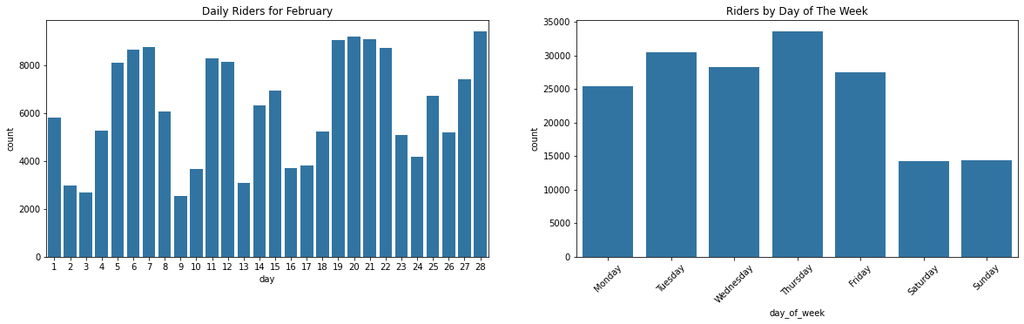

```python
def riders_per_day():
    day_order = ['Monday','Tuesday','Wednesday','Thursday','Friday','Saturday','Sunday']
    plt.figure(figsize=(20,5))
    plt.subplot(1,2,1)
    sb.countplot(data=gobike, x='day', color=base_color)
    plt.title('Daily Riders for February')


    plt.subplot(1,2,2)
    sb.countplot(data=gobike, x='day_of_week', order = day_order, color=base_color)
    plt.xticks(rotation=45);
    plt.title('Riders by Day of The Week');
riders_per_day()
```

- Looking at both days of the month, and days of the week, weekends do not seem as popular with riders as weekdays are. Which is interesting because I would imagnine weekends to be more popular with riders. If we look at user type and day of the week, maybe there is more information to gain from that insight.

```python
# extract the time of day out of start_time
gobike['time'] = gobike['start_time'].dt.strftime('%H:%M:%S')
```

```python
# create time of day sessions
gobike=gobike.assign(session=pd.cut(gobike.time,['0','12','18','23'],
                            labels=['Morning','Afternoon','Evening'],
                            include_lowest=True))
```

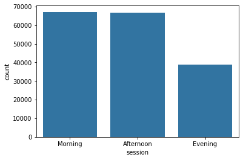

```python
sb.countplot(data=gobike, x='session', color=base_color);
```

- Morning and Afternoon sessions are when majority of the rides took place.

### User Type

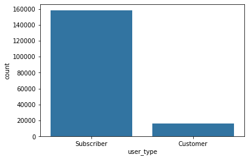

```python
sb.countplot(data=gobike, x='user_type', color=base_color);
```

- Looking at the chart we can see most of the customers are 'Subscribers'.

### Distance traveled by riders

```python
# create coordinates to calculate distance
gobike['start_coord'] = [', '.join(str(x) for x in y)
                     for y in map(tuple, gobike[['start_station_latitude', 'start_station_longitude']].values)]
gobike['end_coord'] = [', '.join(str(x) for x in y)
                     for y in map(tuple, gobike[['end_station_latitude', 'end_station_longitude']].values)]
```

```python
# calculate distance traveled by riders
import geopy.distance
from geopy.distance import geodesic
def distance (row):
    start = (row['start_station_latitude'], row['start_station_longitude'])
    stop = (row['end_station_latitude'], row['end_station_longitude'])

    return geodesic(start, stop).miles
gobike['distance'] = gobike.apply (lambda row: distance(row),axis=1)
```

```python
# drop the single outlier in distance column that is skewing the graph
gobike = gobike.drop(gobike[gobike.distance > 10].index)
```

```python
gobike.distance.describe()
```

```
count    174137.000000
mean          1.050363
std           0.672875
min           0.000000
25%           0.565309
50%           0.887796
75%           1.382611
max           9.762460
Name: distance, dtype: float64
```

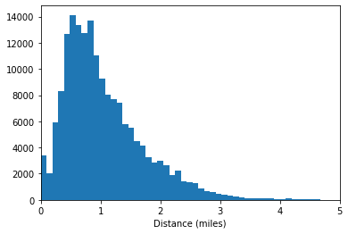

```python
plt.hist(data=gobike, x='distance', bins=100)
plt.xlim(0,5)
plt.xlabel('Distance (miles)');
```

- The distance taveled by most bikers were less than 5 miles. Majority of the numbers are actually below 3 miles.

### Discuss the distribution(s) of your variable(s) of interest. Were there any unusual points? Did you need to perform any transformations?

> At first glance the distance traveled for bikers were clustered around 1 mile because of an outlier. I changed the x-axis limit to 5 miles to get a closer look at the numbers.

## Bivariate Exploration

> In this section, I will investigate relationships between pairs of variables in the dataset.

### Rider age and gender distribution

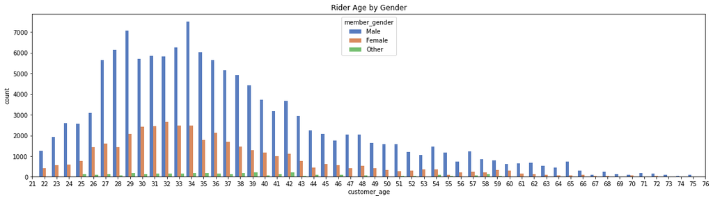

```python
plt.figure(figsize=(20,5))
sb.countplot(data=gobike, x='customer_age', hue='member_gender', palette='muted')
plt.xlim(0,55)
plt.title('Rider Age by Gender');
```

- Upon closer inspection we can conclude male customers who are between the age of 26-42 years of age are the biggest bike renters.

### Rider age and the distance traveled

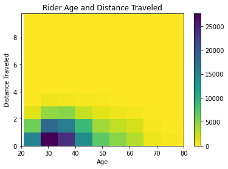

```python
def age_distance():
    group1 = gobike.groupby(['customer_age', 'distance', 'duration_min']).size()
    group1 = group1.reset_index()
    plt.hist2d(data=gobike, x='customer_age', y='distance', cmap='viridis_r')
    plt.xlim(20,80)
    plt.xlabel('Age')
    plt.ylabel('Distance Traveled')
    plt.colorbar()
    plt.title('Rider Age and Distance Traveled')
age_distance()
```

- From the heat map I can clearly see the concentration of age is around 30, and distance traveled is mostly below 3 miles.

### Ride sessions per day of the week

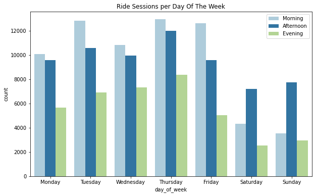

```python
plt.figure(figsize=(10,6))
sb.countplot(data=gobike, x='day_of_week', hue='session', palette="Paired",
             order = day_order)
plt.legend(loc=1)
plt.title('Ride Sessions per Day Of The Week');
```

- Even though weekends are still lower in rental numbers compared to weekdays, weekend afternoons are more busy than weekend morning or evenings. However, lower rental numbers in the morning and evenings make weekends as a whole less busy days of the week. The busiest days/times are Tuesday and Thurday mornings.

### Distance traveled, duration per day of the week

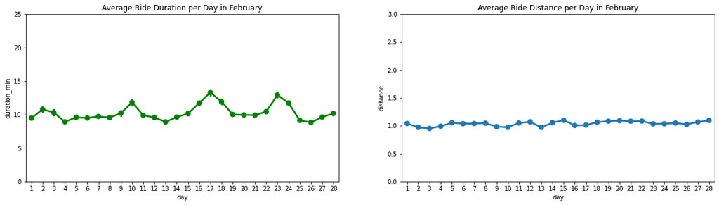

```python
# eliminate outliers from the graphs with ylim()
def day_figures():
    plt.figure(figsize=(20,5))
    plt.subplot(1,2,1)
    sb.pointplot(data=gobike, x='day', y='duration_min',color='green')
    plt.ylim(0,25)
    plt.title('Average Ride Duration per Day in February');


    plt.subplot(1,2,2)
    sb.pointplot(data=gobike, x='day', y='distance', color=base_color)
    plt.ylim(0,3)
    plt.title('Average Ride Distance per Day in February')
day_figures()
```

- Bike rentals duration per day in February all center around a mean of 10 minutes. The distance per day is more unified, with the mean centered around 1 mile.

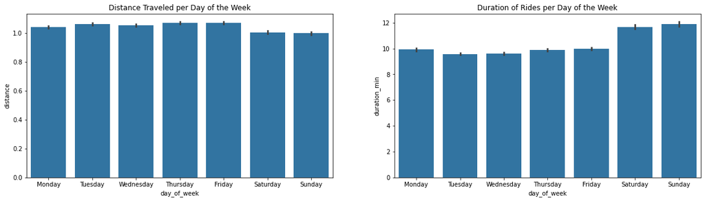

```python
def dayofweek_figs():
    plt.figure(figsize=(20,5))
    plt.subplot(1,2,1)
    sb.barplot(data=gobike, x='day_of_week', y='distance', order=day_order, color=base_color)
    plt.title('Distance Traveled per Day of the Week')


    plt.subplot(1,2,2)
    sb.barplot(data=gobike, x='day_of_week', y='duration_min', order=day_order, color=base_color)
    plt.title('Duration of Rides per Day of the Week')

dayofweek_figs()
```

- Distance traveled is higher during the week, but the rental duration is higher during the weekend.

### Talk about some of the relationships you observed in this part of the investigation. How did the feature(s) of interest vary with other features in the dataset?

> Upon closer inspection we can conclude male customers who are 26-42 years of age are the biggest bike renters. The busiest days/times for bike rentals are Tuesday and Thurday mornings. Weekends are not as busy as weekdays in general, although weekends afternoons are somewhat busier. The slowest rental times of the week are weekend mornings and evening. Time of day, and day of the week did not have any effect on the distance traveled on the bikes.

## Multivariate Exploration

> In this section I created plots of three or more variables to investigate the dataset even further.

### Days of the week, rental duration, and distance traveled

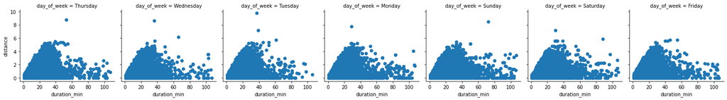

```python
g = sb.FacetGrid(data=gobike, col='day_of_week', margin_titles=True)
g.map(plt.scatter, 'duration_min', 'distance');
```

- This FacetGrid is not particularly illuminating in terms of understanding the relation between days of the week, distance traveled, and rental duration. Most days are similar in distribution except slightly higher concentrations of duration_min on weekends.

### Most used bike stations

```python
# find the station that have more than 2500 riders
gobike['station_counts'] = gobike['start_station_id'].map(gobike['start_station_id'].value_counts())
stations = gobike.station_counts > 2500
gobike_2 = gobike.loc[stations,:]
```

```python
gobike.station_counts.describe()
```

```
count    174137.000000
mean       1098.308361
std         845.142119
min           2.000000
25%         539.000000
50%         801.000000
75%        1418.000000
max        3639.000000
Name: station_counts, dtype: float64
```

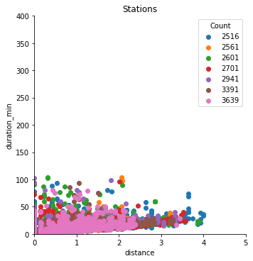

```python
g = sb.FacetGrid(data=gobike_2, hue='station_counts', height=5)
g.map(plt.scatter,'distance','duration_min')
plt.title('Stations')
plt.ylim(0,400)
plt.legend(title='Count')
plt.xlim(0,5);
```

- The color saturation shows some stations are more frequented than others.

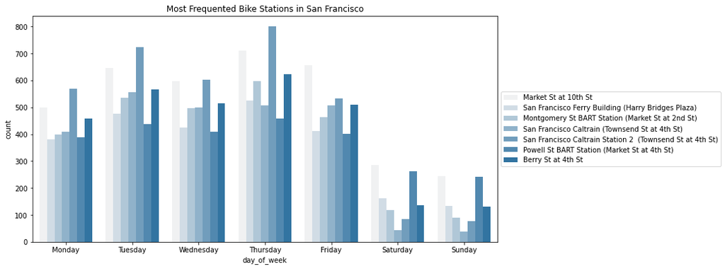

```python
plt.figure(figsize=(12,6))
sb.countplot(data=gobike_2, hue='start_station_name', x='day_of_week',order=day_order, color=base_color)
plt.legend(loc=6, bbox_to_anchor=(1.0, 0.5))
plt.title('Most Frequented Bike Stations in San Francisco');
```

- The top 7 most frequented bike stations per day of the week.

### User type and age based on the day of the week

```python
gobike.user_type.value_counts()
```

```
Subscriber    157893
Customer       16244
Name: user_type, dtype: int64
```

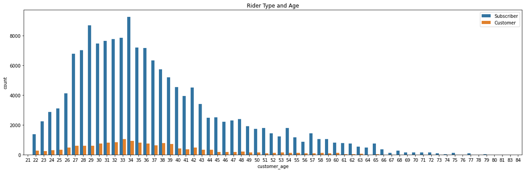

```python
plt.figure(figsize=(20,6))
sb.countplot(data=gobike, x='customer_age', hue='user_type')
plt.legend(loc=1)
plt.title('Rider Type and Age');
```

```python
gobike.member_gender.value_counts()
```

```
Male      129942
Female     40588
Other       3607
Name: member_gender, dtype: int64
```

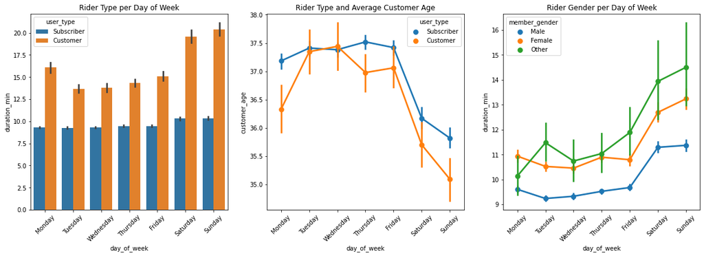

```python
def user_daily():
    plt.figure(figsize=(20,6))
    (plt.subplot(1,3,1))
    sb.barplot(data=gobike, x="day_of_week", y="duration_min",hue='user_type', order=day_order)
    plt.title('Rider Type per Day of Week')
    plt.xticks(rotation=45);

    plt.subplot(1,3,2)
    sb.pointplot(data=gobike, x='day_of_week', y='customer_age', hue='user_type', order=day_order)
    plt.title('Rider Type and Average Customer Age')
    plt.xticks(rotation=45);

    plt.subplot(1,3,3)
    sb.pointplot(data=gobike, x="day_of_week", y="duration_min",hue='member_gender', order=day_order)
    plt.title('Rider Gender per Day of Week')
    plt.xticks(rotation=45);

user_daily()
```